# BIOS 667 - Lecture 11: Generalized Linear Models (Ch. 11)

Fitzmaurice, Laird & Ware (2011) - Applied Longitudinal Data Analysis

Naim Rashid

## Lecture Objectives

By the end of this lecture, you will be able to:

- Describe the three components of a GLM (random, systematic, link)
- Fit and interpret logistic regression for binary outcomes
- Fit and interpret Poisson regression for counts, including overdispersion
- Apply ordinal and multinomial regression for categorical outcomes (instructor extension)
- Diagnose GLM fit using residuals, influence measures, and deviance

**Note**

**Assessment map.** This lecture is assessed on **HW4** (logistic and Poisson interpretation, overdispersion remedies) and **Quiz 4** (GLM components, odds ratios, rate ratios).

## Prerequisites and Recall

Before we generalize, recall what we already have:

| From | What carries forward |
| --- | --- |
| LM (Ch. 3-6) | Linear predictor $X_{ij}\boldsymbol\beta$; least squares; residual diagnostics |
| L10 (Diagnostics) | Residuals, transformed/Mahalanobis residual diagnostics, cluster-influence ideas |
| LM (Ch. 3-6) | Ordinary-regression diagnostics: leverage, Cook’s distance |
| Notation box | $Y_{ij}$, $\mathbf{X}_i$, $\boldsymbol\beta$, indices $i=1,\dots,N$ subjects |

**The leap today:** the response need not be Normal, and effects act on a *transformed* (link) scale, not directly on the mean.

## Roadmap

| Part | Topic | Day |
| --- | --- | --- |
| 1 | Introduction to GLMs | 1 |
| 2 | Logistic regression (binary) | 1 |
| 3 | Poisson regression (counts) | 1 |
| 4 | Ordinal and multinomial models (extension) | 2 |
| 5 | GLM diagnostics | 2 |
| 6 | Extensions and advanced topics (extension) | 2 |
| 7 | Appendices (technical details) | - |

## Notation reference

| Symbol | Meaning |
| --- | --- |
| $Y_{ij}$ | response for subject $i$ at occasion $j$ (scalar) |
| $\mathbf{Y}_i$ | response vector for subject $i$ $(n_i \times 1)$ |
| $\mathbf{X}_i,\ \boldsymbol\beta$ | fixed-effect design $n_i \times p$ and coefficients |
| $\mathbf{Z}_i,\ \mathbf{b}_i$ | random-effect design and random effects, $\mathbf{b}_i \sim N(0, G)$ |
| $G$ | between-subject random-effects covariance (FLW’s letter, Ch. 8) |
| $R_i$ | within-subject residual covariance, $\boldsymbol\varepsilon_i \sim N(0, R_i)$ |
| $\Sigma_i = \mathbf{Z}_i G \mathbf{Z}_i^\top + R_i$ | marginal (total) covariance $\operatorname{Cov}(\mathbf{Y}_i)$ for subject $i$ |
| $\rho$ | correlation parameter (AR(1), exchangeable) |

Indices: $i$ subject $1,\dots,N$; $j$ occasion/time $1,\dots,n_i$ ($n$ when balanced); $k$ state (transition models); $g$ group. **Bold** = vector or matrix.

## Notation (this lecture)

| Symbol | Meaning |
| --- | --- |
| $\pi_{ij}$ | probability of a binary outcome, subject $i$ occasion $j$ |
| $\theta_i$ | natural parameter (a re-parameterization of the mean) |
| $\eta_{ij} = X_{ij}\boldsymbol\beta$ | linear predictor (row form $X_{ij}$, $1\times p$) |
| $g(\mu)=\eta$ | link function; $\mu=g^{-1}(\eta)$ is the inverse link |
| $\phi$ | dispersion (scale) parameter; $\mathrm{Var}(Y)=\phi\,v(\mu)$ |
| $v(\mu)$ | GLM mean-variance function (NOT a covariance matrix) |
| $\kappa_k$ | ordinal cumulative-logit cutpoints, $k=1,\dots,K-1$ (FLW writes $\alpha_k$; we use $\kappa_k$ to avoid the GEE $\alpha$ and the natural parameter $\theta$) |

**Warning**

$v(\mu)$ here is the scalar **variance function** of the mean (e.g. $v(\mu)=\mu$ for Poisson), NOT the GEE working covariance $V_i$ from the notation box.

# Part 1 (Day 1): Introduction to GLMs

Framework, exponential family, link functions, estimation. Pace: ~20-25 min.

## Why Generalized Linear Models?

| Linear Model (LM) Assumption | GLM Extension |
| --- | --- |
| Normally distributed $Y$ | Exponential-family distributions |
| Constant variance | Variance depends on the mean |
| Additive effects on the mean | Additive effects on a transformed (link) scale |

**Non-normal outcomes:** binary, counts, proportions, rates.

## GLM Framework: the idea first

Two plain sentences before any density:

- $\theta_i$ is a **re-parameterization of the mean**, called the *natural parameter*.
- $\phi$ is a **scale / dispersion constant** that sets the variance level.

Everything you need follows from one cumulant function:

| Quantity | Formula |
| --- | --- |
| Mean | $\mathbb{E}(Y_i) = \mu_i$ |
| Variance | $\mathrm{Var}(Y_i) = \phi\,V(\mu_i)$ |

## GLM Framework: the exponential family

Each response $Y_i$ has a density in the exponential family. Using FLW’s notation (eq. 11.3, p. 328):

$$f(y_i \mid \theta_i,\phi) =
\exp\!\left[ \frac{y_i\theta_i - a(\theta_i)}{\phi} + b(y_i,\phi) \right]$$

with $\mathbb{E}(Y_i)=\mu_i=a'(\theta_i)$ and $\mathrm{Var}(Y_i)=\phi\,a''(\theta_i)$.

**Note**

**Notation caution.** FLW (eq. 11.3-11.4) writes the **cumulant function as $a(\theta)$** and the data-only term as $b(y,\phi)$, with the scale entering as $\phi$ directly. Many texts (McCullagh & Nelder) instead write $\{y\theta - b(\theta)\}/a(\phi) + c(y,\phi)$. The roles are the same; only the letters differ. We follow FLW here.

## Exponential Family: a concrete example

For **Poisson** with mean $\mu$ (here $\phi=1$):

- Natural parameter: $\theta = \log(\mu)$
- Cumulant function: $a(\theta) = e^\theta = \mu$
- $a'(\theta) = e^\theta = \mu$ (the mean)
- $a''(\theta) = e^\theta = \mu$ (the variance)

**Insight:** for Poisson, mean $=$ variance. This falls out of the family automatically.

## GLM Components

| Component | Description | Example |
| --- | --- | --- |
| Random | $Y_i$ from exponential family | binary, count |
| Systematic | Linear predictor $\eta_{ij} = X_{ij}\boldsymbol{\beta}$ | $\eta=\beta_0+\beta_1 x$ |
| Link | $g(\mu_i)=\eta_i$ | logit, log, identity |

Here $X_{ij}$ is the **row** of covariates ($1\times p$), so the mean model is $X_{ij}\boldsymbol\beta$.

## Canonical Links

| Distribution | Mean-Variance | Canonical Link |
| --- | --- | --- |
| Normal | $\mu,\;\sigma^2$ | identity |
| Binomial | $\pi,\;\pi(1-\pi)$ | logit |
| Poisson | $\mu,\;\mu$ | log |
| Gamma | $\mu,\;\mu^2$ | inverse |

## Estimation: maximum likelihood

GLM coefficients $\boldsymbol\beta$ are estimated by **maximum likelihood** (FLW Section 11.7). FLW states only this; the algorithm below is standard GLM theory.

**Note**

**Beyond FLW Ch. 11 (instructor extension).** The IRLS algorithm and the score / Fisher-information formulas are standard GLM theory (McCullagh & Nelder 1989; Dobson & Barnett 2018). FLW Ch. 11 only states that estimation is by ML. The intuition slides that follow are supplementary; full details are in Appendix A-B.

## IRLS: The Intuition

**Think of IRLS as “smart” weighted regression that learns as it goes:**

| Step | What Happens | Analogy |
| --- | --- | --- |
| 1. Initialize | Start with a guess (e.g. $\hat\mu_i=\bar y$) | First draft |
| 2. Compute weights | Upweight observations we are more certain about | Focus attention |
| 3. Fit weighted regression | Solve linear system with current weights | Refine estimate |
| 4. Update predictions | New $\hat\mu_i$ from updated $\hat{\boldsymbol\beta}$ | Revised draft |
| 5. Repeat | Until estimates stabilize | Final answer |

**Key insight:** higher-variance observations get lower weights, so uncertain points have less influence.

## IRLS: Why Iteration?

Unlike OLS, GLMs have a **nonlinear** link between parameters and predictions.

**OLS:** one-shot solution $(\mathbf{X}^\top\mathbf{X})^{-1}\mathbf{X}^\top\mathbf{Y}$.

**GLM:** weights depend on $\mu_i$, which depends on $\boldsymbol\beta$, which depends on the weights…

**Solution:** iterate to convergence. Start somewhere reasonable, improve step by step. In R, `glm()` handles this automatically (it warns if there are convergence problems).

**Check Your Understanding: GLM Fundamentals**

1. What are the three components of a GLM, and what does each do?
2. Why does the Poisson distribution have mean equal to variance? (Hint: the exponential family.)
3. In IRLS, why iterate rather than compute a one-shot solution like OLS?

**Answers:**

1. 1. **Random component**: the distribution of $Y_i$ (binomial, Poisson, …). (2) **Systematic component**: the linear predictor $\eta_{ij}=X_{ij}\boldsymbol\beta$. (3) **Link**: $g(\mu_i)=\eta_i$ connects the mean to the linear predictor.
2. For Poisson the cumulant function is $a(\theta)=e^\theta$. Mean $=a'(\theta)=e^\theta=\mu$ and variance $=a''(\theta)=e^\theta=\mu$, so they are equal.
3. The weights depend on $\mu_i$, which depends on $\boldsymbol\beta$. There is no closed form, so we alternate between updating weights and updating $\boldsymbol\beta$ until convergence.

# Part 2 (Day 1): Logistic Regression

Binary outcomes: model, odds ratios, fitted probabilities, real-data case study. Pace: ~25-30 min.

## Interpreting Logistic Coefficients

Model on the log-odds scale:

$$\log\!\left(\frac{\pi}{1-\pi}\right) = \beta_0 + \beta_1 x_1 + \cdots + \beta_p x_p$$

| Quantity | Interpretation |
| --- | --- |
| $\beta_j$ | Change in log-odds per unit increase in $x_j$ |
| $e^{\beta_j}$ | Odds ratio (OR) |
| $e^{\beta_j} > 1$ | Odds of $Y=1$ increase |
| $e^{\beta_j} < 1$ | Odds of $Y=1$ decrease |

## Case Study: TLC Lead-Exposure Trial (real data)

**Note**

**Real FLW dataset (instructor-defined binary endpoint).** TLC is FLW’s lead-exposure trial (Ch. 5/6): 100 children randomized to succimer or placebo, blood lead measured at weeks 0, 1, 4, 6. FLW Ch. 5/6 analyze it as a *continuous* longitudinal response. Here we define an **instructor binary endpoint** – *elevated lead at week 6* ($\ge 20\ \mu g/dL$) – to illustrate logistic regression on real data. The cutoff is a teaching choice, not an FLW analysis.

```r
tlc <- tlc |>
  dplyr::mutate(elevated_w6 = as.integer(w6 >= 20))   # 1 = elevated lead at wk 6
table(Treatment = tlc$trt, Elevated_wk6 = tlc$elevated_w6)
```

## Case Study: TLC Lead-Exposure Trial (real data)

```
          Elevated_wk6
Treatment   0  1
  Placebo  13 37
  Succimer 27 23
```

## Logistic GLM: Fit

```r
fit_logit <- glm(elevated_w6 ~ trt + w0, data = tlc, family = binomial)
summary(fit_logit)
```

## Logistic GLM: Fit

```
Call:
glm(formula = elevated_w6 ~ trt + w0, family = binomial, data = tlc)

Coefficients:
            Estimate Std. Error z value Pr(>|z|)
(Intercept) -6.07274    1.64543  -3.691 0.000224 ***
trtSuccimer -1.70470    0.52826  -3.227 0.001251 **
w0           0.28754    0.06802   4.227 2.37e-05 ***
---
Signif. codes:  0 '***' 0.001 '**' 0.01 '*' 0.05 '.' 0.1 ' ' 1

(Dispersion parameter for binomial family taken to be 1)

    Null deviance: 134.602  on 99  degrees of freedom
Residual deviance:  99.233  on 97  degrees of freedom
AIC: 105.23

Number of Fisher Scoring iterations: 5
```

## Logistic: Odds Ratios and CIs

```r
or_tab <- broom::tidy(fit_logit, conf.int = TRUE) |>
  dplyr::mutate(OR = exp(estimate),
                OR_low = exp(conf.low),
                OR_high = exp(conf.high)) |>
  dplyr::select(term, estimate, OR, OR_low, OR_high, p.value)
or_tab
```

## Logistic: Odds Ratios and CIs

```
# A tibble: 3 × 6
  term        estimate      OR    OR_low OR_high   p.value
  <chr>          <dbl>   <dbl>     <dbl>   <dbl>     <dbl>
1 (Intercept)   -6.07  0.00230 0.0000702  0.0467 0.000224
2 trtSuccimer   -1.70  0.182   0.0606     0.490  0.00125
3 w0             0.288 1.33    1.18       1.54   0.0000237
```

## Plain-Language Interpretation: Logistic Output

| Term | OR | Interpretation |
| --- | --- | --- |
| `(Intercept)` | – | Baseline log-odds when covariates are 0 |
| `trtSuccimer` | 0.18 | Succimer multiplies the odds of elevated lead at wk 6 by 0.18 vs placebo |
| `w0` | 1.33 | Each 1 $\mu g/dL$ higher baseline lead multiplies the odds by 1.33 |

**In a sentence:** adjusting for baseline lead, the succimer odds ratio for remaining elevated at week 6 is 0.18 (below 1, i.e. lower odds than placebo), and the baseline-lead odds ratio is 1.33 (above 1, i.e. higher baseline raises the odds).

## From Coefficients to Predicted Probabilities

Logistic inverse link (row form):

$$\hat\pi_{ij} = \frac{e^{X_{ij}\hat{\boldsymbol\beta}}}{1 + e^{X_{ij}\hat{\boldsymbol\beta}}}$$

In R, `predict(fit, type = "response")` returns $\hat\pi_{ij}$.

```r
tlc$pred_prob <- predict(fit_logit, type = "response")
head(tlc[, c("trt", "w0", "elevated_w6", "pred_prob")])
```

## From Coefficients to Predicted Probabilities

```
       trt   w0 elevated_w6 pred_prob
1  Placebo 30.8           1 0.9417841
2 Succimer 26.5           1 0.4607010
3 Succimer 25.8           1 0.4112497
4  Placebo 24.7           1 0.7368379
5 Succimer 20.4           0 0.1288079
6 Succimer 20.4           0 0.1288079
```

## Visualize Fitted Probabilities

```r
newdat <- expand.grid(
  trt = levels(tlc$trt),
  w0  = seq(min(tlc$w0), max(tlc$w0), length = 100)
)
newdat$pred_prob <- predict(fit_logit, newdata = newdat, type = "response")
ggplot(newdat, aes(w0, pred_prob, color = trt)) +
  geom_line(linewidth = 1.2) +
  labs(y = "Predicted P(elevated at wk 6)", x = "Baseline lead (wk 0)",
       title = "Logistic Fitted Probabilities: TLC Trial",
       color = "Treatment") +
  theme_minimal()
```

## Visualize Fitted Probabilities

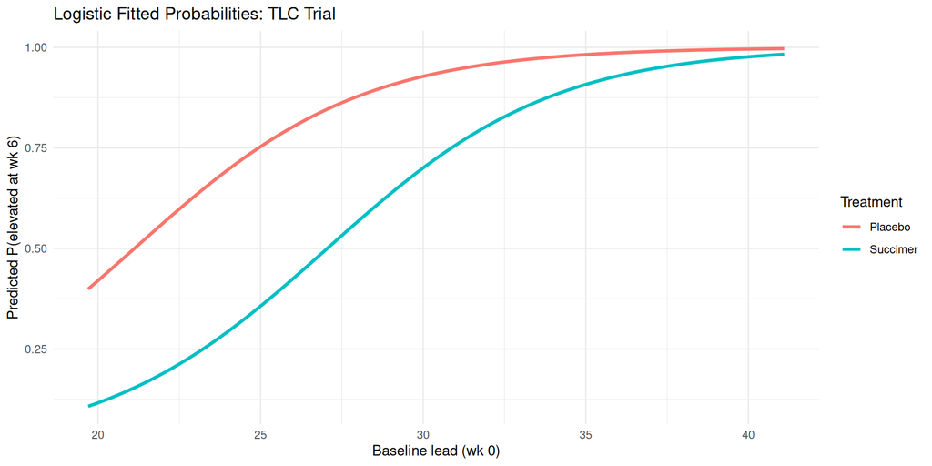

## Static SAS: PROC LOGISTIC (reference only)

The same TLC logistic model in SAS (FLW Section 11.6 uses PROC GENMOD/LOGISTIC):

```sas
proc logistic data=tlc descending;
   class trt (ref="Placebo") / param=ref;
   model elevated_w6 = trt w0;
   /* odds ratios printed automatically; oddsratio for custom contrasts */
run;
```

**Note**

Shown for reference only, not executed. `descending` models $P(Y=1)$; `class ... param=ref` matches R’s reference coding.

# Part 2b (Day 2 enrichment): Classification and Calibration

**Note**

**Beyond FLW Ch. 11 (instructor extension).** Classification thresholds, confusion matrices, sensitivity/specificity, ROC/AUC, calibration plots, the Hosmer-Lemeshow test, and residual/influence diagnostics for GLMs are **not** in FLW Ch. 11 (which covers odds-ratio interpretation, ML, and Wald tests for binary data). They are standard applied-logistic tools: see Hosmer, Lemeshow & Sturdivant (2013) and Pepe (2003) for ROC/calibration; Agresti (2015) for the modeling context. Recognize them; they are enrichment, not examinable Ch. 11 content.

## Using Probabilities for Classification

Choose a threshold $t$ and predict:

$$\widehat Y =
\begin{cases}
1, & \hat\pi \ge t \\
0, & \text{otherwise}
\end{cases}$$

Default $t=0.5$, but it can be tuned to the application’s costs.

```r
tlc$pred_class_05 <- ifelse(tlc$pred_prob >= 0.5, 1, 0)
table(Predicted = tlc$pred_class_05, Observed = tlc$elevated_w6)
```

## Using Probabilities for Classification

```
         Observed
Predicted  0  1
        0 25 15
        1 15 45
```

```r
mean(tlc$pred_class_05 == tlc$elevated_w6)   # accuracy at t = 0.5
```

```
[1] 0.7
```

## Sensitivity, Specificity, and FPR

| Metric | Definition |
| --- | --- |
| Sensitivity (TPR) | $P(\widehat Y=1 \mid Y=1)$ |
| Specificity (TNR) | $P(\widehat Y=0 \mid Y=0)$ |
| False positive rate (FPR) | $1 - \text{Specificity} = P(\widehat Y=1 \mid Y=0)$ |

Varying the threshold traces an **ROC curve** (TPR on the $y$-axis vs FPR on the $x$-axis).

## ROC Curve and AUC

```r
suppressPackageStartupMessages(library(pROC))
roc_obj <- roc(tlc$elevated_w6, tlc$pred_prob, quiet = TRUE)
plot(roc_obj, main = paste0("TLC Logistic ROC (AUC = ", round(auc(roc_obj), 3), ")"))
```

**Note**

**Reading it:** a curve hugging the top-left corner = good discrimination; the diagonal = no better than chance (AUC 0.5). AUC = probability a random positive is ranked above a random negative.

## ROC Curve and AUC

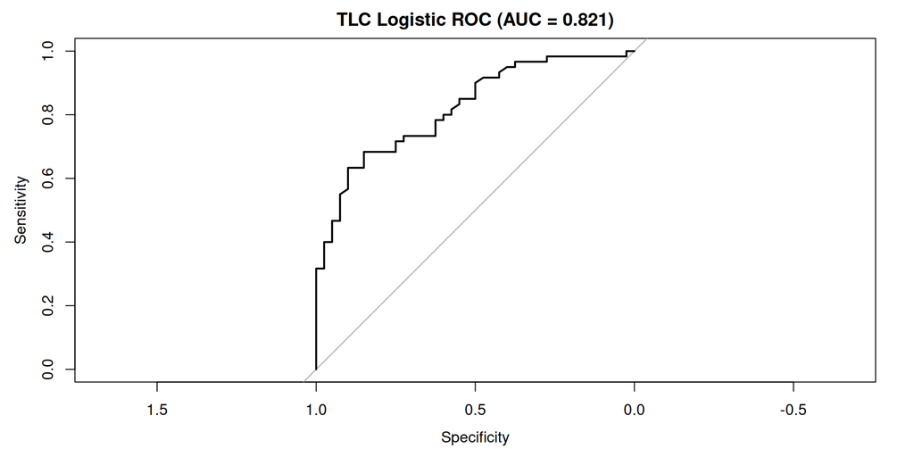

## Interpreting AUC

**Note**

**Beyond FLW (rule-of-thumb thresholds).** These cutoffs follow Hosmer, Lemeshow & Sturdivant (2013); they are conventions, not FLW content, and are sensitive to context.

| AUC Range | Discrimination (Hosmer-Lemeshow convention) |
| --- | --- |
| 0.5 | No discrimination |
| 0.7-0.8 | Acceptable |
| 0.8-0.9 | Excellent |
| > 0.9 | Outstanding (rare) |

## Calibration: Predicted vs Observed

```r
dd <- tlc |>
  dplyr::mutate(dec = cut(pred_prob,
                          breaks = quantile(pred_prob, probs = seq(0, 1, 0.1), na.rm = TRUE),
                          include.lowest = TRUE)) |>
  dplyr::group_by(dec) |>
  dplyr::summarise(mean_pred = mean(pred_prob),
                   obs_rate  = mean(elevated_w6),
                   n = dplyr::n(), .groups = "drop")
ggplot(dd, aes(mean_pred, obs_rate, size = n)) +
  geom_point(alpha = 0.8) +
  geom_abline(slope = 1, intercept = 0, linetype = "dashed") +
  labs(title = "TLC Logistic Calibration (deciles of predicted risk)",
       x = "Mean predicted probability", y = "Observed event rate") +
  theme_minimal()
```

**Note**

**Reading it:** points on the dashed 45-degree line = well calibrated (predicted matches observed). Points above the line = model under-predicts risk; below = over-predicts. A high AUC does NOT guarantee good calibration.

## Calibration: Predicted vs Observed

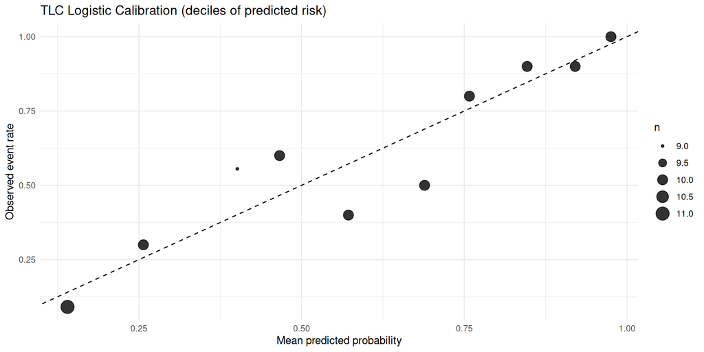

## Logistic Diagnostics: Residuals

```r
res_df <- data.frame(
  fitted = fitted(fit_logit),
  dev    = residuals(fit_logit, type = "deviance"),
  pear   = residuals(fit_logit, type = "pearson")
)
p1 <- ggplot(res_df, aes(fitted, dev)) + geom_point(alpha = .6) +
  geom_hline(yintercept = 0, linetype = "dashed") +
  labs(title = "Deviance Residuals vs Fitted") + theme_bw()
p2 <- ggplot(res_df, aes(fitted, pear)) + geom_point(alpha = .6) +
  geom_hline(yintercept = 0, linetype = "dashed") +
  labs(title = "Pearson Residuals vs Fitted") + theme_bw()
print(p1); print(p2)
```

**Note**

**Reading it:** for binary data residuals split into two bands (one per outcome), so do not expect a random cloud. Look for points far from 0 (poorly fit observations) and any systematic curvature (possible link misspecification), not for constant spread.

## Logistic Diagnostics: Residuals

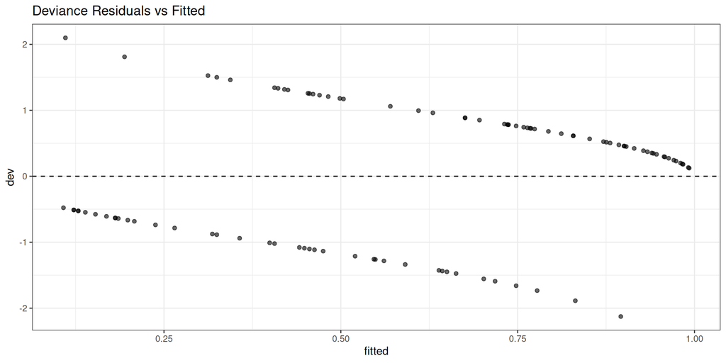

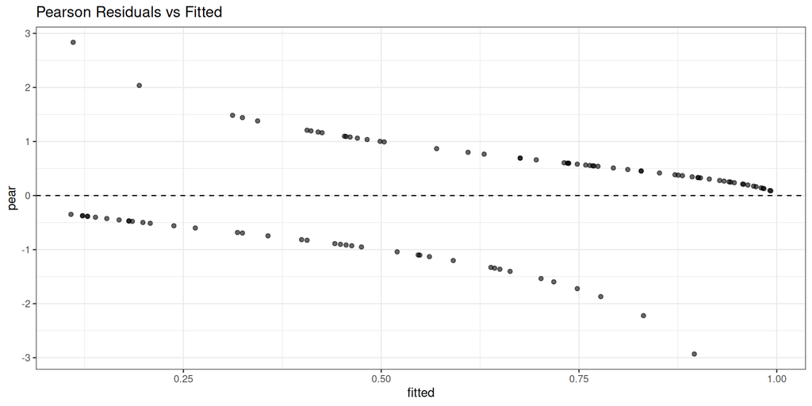

## Influence and Leverage

```r
lev <- hatvalues(fit_logit)
cd  <- cooks.distance(fit_logit)
par(mfrow = c(1, 2))
plot(lev, type = "h", main = "Leverage (hat values)", ylab = "hat")
abline(h = 2 * mean(lev), col = "red", lty = 2)
plot(cd, type = "h", main = "Cook's Distance", ylab = "Cook's D")
abline(h = 4 / length(cd), col = "red", lty = 2)
```

**Note**

**Reading it:** the red lines are common rules of thumb – leverage above $2\bar h$ (twice the average hat value) is high-leverage; Cook’s D above $4/n$ flags an influential point. Points crossing both deserve a look (refit without them to gauge sensitivity).

## Influence and Leverage

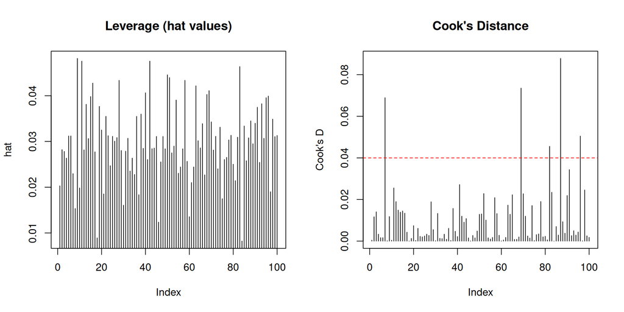

```r
par(mfrow = c(1, 1))
```

## Goodness-of-Fit: Hosmer-Lemeshow

```r
if (requireNamespace("ResourceSelection", quietly = TRUE)) {
  hl <- ResourceSelection::hoslem.test(tlc$elevated_w6, fitted(fit_logit), g = 10)
  hl
} else {
  cat("Install 'ResourceSelection' for the Hosmer-Lemeshow test.\n")
}
```

**Note**

**Reading it:** large p-value = no evidence of poor fit; small p-value = misfit. Caveat: the result is sensitive to the number of groups $g$ (try a few). This is an enrichment GOF tool; FLW’s native fit assessment is deviance / likelihood-ratio tests.

## Goodness-of-Fit: Hosmer-Lemeshow

```
    Hosmer and Lemeshow goodness of fit (GOF) test

data:  tlc$elevated_w6, fitted(fit_logit)
X-squared = 5.4331, df = 8, p-value = 0.7104
```

## Logistic Models: Quick Checklist

| Step | Action |
| --- | --- |
| Coefficients | Exponentiate to odds ratios |
| Predictions | Use `type="response"` for probabilities |
| Classification* | Choose a threshold by context |
| Discrimination* | ROC / AUC |
| Calibration* | Predicted vs observed |
| Diagnostics* | Residuals, leverage, influence |

* enrichment beyond FLW Ch. 11.

**Check Your Understanding: Logistic Regression**

1. If $\hat\beta = 0.7$ for treatment, what is the odds ratio and how do you read it?
2. If $P(Y=1)=0.2$, what are the odds?
3. An AUC of 0.75 means what in plain English?

**Answers:**

1. OR $=e^{0.7}=2.01$: the odds of the outcome in the treatment group are about twice the odds in control, adjusting for other covariates.
2. Odds $=0.2/0.8=0.25$ (“1 to 4”).
3. Pick one positive and one negative at random; there is a 75% chance the model gives the positive the higher predicted probability (acceptable discrimination).

# Part 3 (Day 1): Poisson Regression

Count outcomes: rates, offsets, overdispersion, quasi-Poisson and NB remedies, on real data. Pace: ~25-30 min.

## Transition to Count Outcomes

**Counts** (number of events) call for the Poisson family.

| Aspect | Consideration |
| --- | --- |
| Distribution | Poisson: $\mathrm{Var}(Y)=\mu$ |
| Rate modeling | use an `offset(log(exposure))` |
| Common issue | overdispersion ($\mathrm{Var}>\mu$) |
| Remedies | quasi-Poisson, negative binomial |

## Case Study: Epilepsy Seizure-Count Trial (real data)

**Note**

**Real FLW dataset (Thall & Vail 1990; FLW Ch. 11/13/14).** 59 epileptics randomized to progabide or placebo. Baseline = seizure count over an 8-week run-in; outcome = total seizures over the four 2-week post-randomization visits (8 weeks). We model the **rate** with an `offset(log(8))` for the 8-week exposure window.

```r
str(ep[, c("id", "trtf", "age", "base", "total")])
```

## Case Study: Epilepsy Seizure-Count Trial (real data)

```
'data.frame':   59 obs. of  5 variables:
 $ id   : int  1 2 3 4 5 6 7 8 9 10 ...
 $ trtf : Factor w/ 2 levels "Placebo","Progabide": 1 1 1 1 1 1 1 1 1 1 ...
 $ age  : int  31 30 25 36 22 29 31 36 37 28 ...
 $ base : int  11 11 6 8 66 27 12 52 23 10 ...
 $ total: int  14 14 11 13 55 22 12 95 22 33 ...
```

```r
summary(ep$total)
```

```
   Min. 1st Qu.  Median    Mean 3rd Qu.    Max.
   0.00   11.50   16.00   33.08   36.00  302.00
```

## Fit Poisson GLM (with offset)

```r
ep$logexp <- log(8)   # 8 post-randomization weeks of observation
fit_pois <- glm(total ~ trtf + base + age + offset(logexp),
                data = ep, family = poisson)
summary(fit_pois)
```

## Fit Poisson GLM (with offset)

```
Call:
glm(formula = total ~ trtf + base + age + offset(logexp), family = poisson,
    data = ep)

Coefficients:
                Estimate Std. Error z value Pr(>|z|)
(Intercept)    0.0749927  0.1198240   0.626    0.531
trtfProgabide -0.1928933  0.0464638  -4.151 3.30e-05 ***
base           0.0225023  0.0005121  43.945  < 2e-16 ***
age            0.0162527  0.0035126   4.627 3.71e-06 ***
---
Signif. codes:  0 '***' 0.001 '**' 0.01 '*' 0.05 '.' 0.1 ' ' 1

(Dispersion parameter for poisson family taken to be 1)

    Null deviance: 2119.60  on 58  degrees of freedom
Residual deviance:  569.28  on 55  degrees of freedom
AIC: 860.71

Number of Fisher Scoring iterations: 5
```

## Poisson GLM: Interpret Rate Ratios

- $e^{\hat\beta_{\text{Progabide}}} =$ 0.82
- $e^{\hat\beta_{\text{base}}} =$ 1.023 per additional baseline seizure

**Interpretation:** adjusting for baseline count and age, progabide is associated with a seizure rate 0.82 times that of placebo (a 18% lower rate point estimate). Each extra baseline seizure multiplies the rate by 1.023.

**Warning**

We will see the SEs here are **too small** (invalid inference) because of overdispersion; do not over-read the significance until we correct it.

## Plain-Language Interpretation: Poisson Output

| Term | Rate Ratio | Interpretation |
| --- | --- | --- |
| `(Intercept)` | – | Baseline log-rate (placebo, base=0, age=0) |
| `trtfProgabide` | 0.82 | Progabide vs placebo seizure-rate ratio |
| `base` | 1.023 | Each extra baseline seizure scales the rate |
| `age` | 1.016 | Per-year multiplicative change in rate |
| `offset(logexp)` | fixed | Adjusts for the 8-week exposure window |

**Note on the offset:** the offset makes us model *rates* (events per unit time), not raw counts, so subjects with different follow-up are compared fairly.

## Visualize Fitted Rates

```r
newd <- expand.grid(
  age   = seq(min(ep$age), max(ep$age), length.out = 100),
  trtf  = levels(ep$trtf),
  base  = median(ep$base),
  logexp = log(8)
)
newd$pred <- predict(fit_pois, newdata = newd, type = "response")
ggplot(newd, aes(age, pred, color = trtf)) +
  geom_line(linewidth = 1.1) +
  labs(y = "Predicted seizures / 8 weeks", x = "Age",
       title = "Poisson GLM: Predicted Seizure Count (at median baseline)",
       color = "Treatment") +
  theme_minimal()
```

## Visualize Fitted Rates

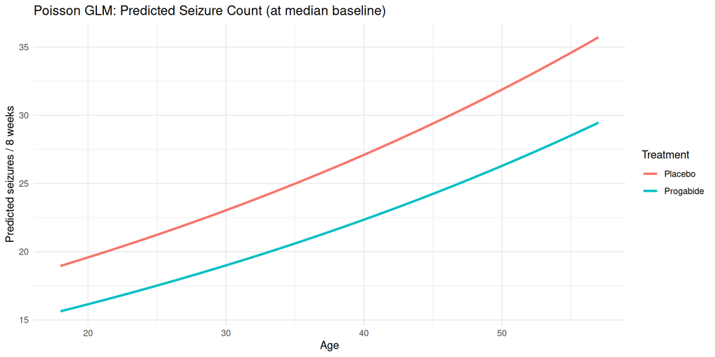

## Poisson Diagnostics: Pearson Residuals

```r
pp <- tibble(fitted = fitted(fit_pois),
             rpear  = residuals(fit_pois, type = "pearson"))
ggplot(pp, aes(fitted, rpear)) +
  geom_point(alpha = .6) +
  geom_hline(yintercept = 0, linetype = "dashed") +
  labs(title = "Epilepsy Poisson: Pearson Residuals vs Fitted") +
  theme_bw()
```

**Note**

**Reading it:** under a correct Poisson model the Pearson residuals should sit roughly within $\pm 2$ with constant spread. A **fanning** pattern (spread growing with the fitted value) and many residuals far beyond $\pm 2$ signal **overdispersion** – the variance grows faster than the mean.

## Poisson Diagnostics: Pearson Residuals

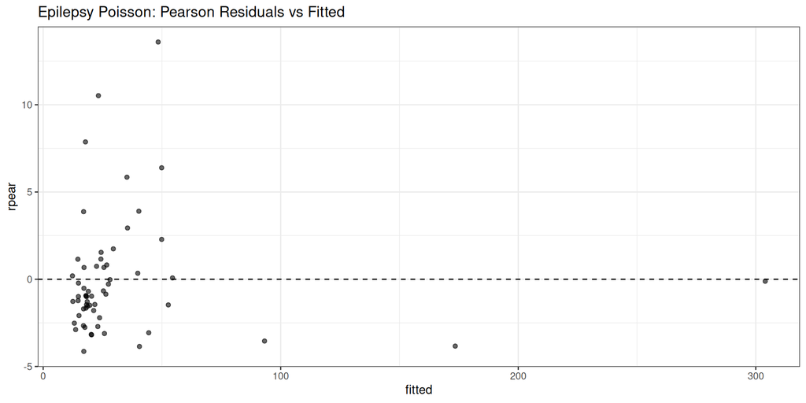

## Checking for Overdispersion

```r
phi_hat <- sum(residuals(fit_pois, type = "pearson")^2) / fit_pois$df.residual
phi_hat
```

If $\hat\phi > 1$, the variance exceeds the mean (overdispersion). Here $\hat\phi$ is far above 1, so the Poisson SEs are **too small** (invalid inference).

**Remedy:** quasi-Poisson or negative binomial.

## Checking for Overdispersion

```
[1] 12.04789
```

## Quasi-Poisson Model

```r
fit_qp <- glm(total ~ trtf + base + age + offset(logexp),
              data = ep, family = quasipoisson)
summary(fit_qp)
```

## Quasi-Poisson Model

```
Call:
glm(formula = total ~ trtf + base + age + offset(logexp), family = quasipoisson,
    data = ep)

Coefficients:
               Estimate Std. Error t value Pr(>|t|)
(Intercept)    0.074993   0.415910   0.180    0.858
trtfProgabide -0.192893   0.161276  -1.196    0.237
base           0.022502   0.001777  12.660   <2e-16 ***
age            0.016253   0.012192   1.333    0.188
---
Signif. codes:  0 '***' 0.001 '**' 0.01 '*' 0.05 '.' 0.1 ' ' 1

(Dispersion parameter for quasipoisson family taken to be 12.04789)

    Null deviance: 2119.60  on 58  degrees of freedom
Residual deviance:  569.28  on 55  degrees of freedom
AIC: NA

Number of Fisher Scoring iterations: 5
```

## Compare Poisson vs Quasi-Poisson

| Model | Dispersion | SE behavior | Consequence |
| --- | --- | --- | --- |
| Poisson | fixed $=1$ | too small if $\mathrm{Var}>\mu$ | inflated significance (invalid inference) |
| Quasi-Poisson | estimated $\hat\phi$ | scaled by $\sqrt{\hat\phi}$ | coefficients unchanged, SEs corrected |

## Negative Binomial

```r
fit_nb <- glm.nb(total ~ trtf + base + age + offset(logexp), data = ep)
summary(fit_nb)
```

**Note**

NB models the variance as $\mu + \mu^2/k$ (an extra parameter $k$), a more flexible mean-variance relationship than quasi-Poisson’s constant scaling. Both correct the SEs; they assume different variance forms.

## Negative Binomial

```
Call:
glm.nb(formula = total ~ trtf + base + age + offset(logexp),
    data = ep, init.theta = 3.328492494, link = log)

Coefficients:
               Estimate Std. Error z value Pr(>|z|)
(Intercept)    0.019042   0.358599   0.053    0.958
trtfProgabide -0.214854   0.153943  -1.396    0.163
base           0.027621   0.002835   9.744   <2e-16 ***
age            0.011383   0.010683   1.066    0.287
---
Signif. codes:  0 '***' 0.001 '**' 0.01 '*' 0.05 '.' 0.1 ' ' 1

(Dispersion parameter for Negative Binomial(3.3285) family taken to be 1)

    Null deviance: 179.749  on 58  degrees of freedom
Residual deviance:  63.647  on 55  degrees of freedom
AIC: 477.23

Number of Fisher Scoring iterations: 1

              Theta:  3.328
          Std. Err.:  0.701

 2 x log-likelihood:  -467.225
```

## Static SAS: PROC GENMOD with offset (reference only)

The epilepsy Poisson rate model in SAS (FLW Section 11.6, Table 11.9 style):

```sas
data ep; set ep; logexp = log(8); run;

proc genmod data=ep;
   class trtf (ref="Placebo") / param=ref;
   model total = trtf base age / dist=poisson link=log offset=logexp;
   /* for overdispersion, add  dscale  to scale the SEs by sqrt(Pearson/df) */
run;

/* negative binomial alternative */
proc genmod data=ep;
   class trtf (ref="Placebo") / param=ref;
   model total = trtf base age / dist=negbin link=log offset=logexp;
run;
```

**Note**

Shown for reference only, not executed. `offset=logexp` mirrors R’s `offset(log(8))`; `dscale` is SAS’s overdispersion scale factor.

**Check Your Understanding: Poisson Regression**

1. What does $\hat\phi = 2.5$ tell you about a Poisson model?
2. If $\hat\beta=0.68$ for “chronic condition,” what is the rate ratio and its reading?
3. Key difference between quasi-Poisson and negative binomial?

**Answers:**

1. Overdispersion: observed variance about 2.5x the Poisson assumption (variance = mean). The Poisson SEs are too small, inflating significance.
2. Rate ratio $=e^{0.68}=1.97$: the event rate is about 1.97x for those with the condition, holding other covariates fixed.
3. Quasi-Poisson scales the variance by a constant $\phi$ (SEs $\times\sqrt\phi$, coefficients unchanged); NB adds a parameter so $\mathrm{Var}=\mu+\mu^2/k$. Both fix the SEs but assume different variance structures.

# Part 4 (Day 2): Ordinal and Multinomial Models

**Note**

**Beyond FLW Ch. 11 (instructor extension).** Proportional-odds (ordinal) and multinomial regression are introduced briefly in FLW only via the cumulative-logit example; the modeling depth here (polr, multinom, PO assumption) follows McCullagh (1980) and Agresti (2015). Recognize the models; treat as enrichment. Pace: ~20 min.

## Ordinal Response Setup

Ordered categories (e.g. symptom severity: Low $<$ Med $<$ High).

**Proportional-odds model (POM), R/`polr` convention:**

$$\log\!\left(\frac{P(Y\le k)}{P(Y>k)}\right)=\kappa_k - X_{ij}\boldsymbol{\beta},
\qquad k=1,\dots,K-1$$

**Note**

**Sign convention (read carefully).** The $\kappa_k$ are $K-1$ **increasing cutpoints** (FLW eq. (11.1), p. 313, writes these as $\alpha_k$; we use $\kappa_k$ to avoid the GEE working-correlation $\alpha$ and the GLM natural parameter $\theta$). R’s `polr` uses the **minus-sign** form above, so a **positive $\beta$ pushes probability toward HIGHER categories.** FLW’s eq. (11.1) uses the **plus-sign** form $\mathrm{logit}\,P(Y\le k)=\alpha_k + X_{ij}\boldsymbol\beta$, under which the sign is reversed. FLW (p. 313) explicitly warns the two conventions differ. We use the `polr` (minus) form so code and slides agree.

## Simulate Ordinal Data

**Note**

Simulated to isolate the proportional-odds mechanism (no real FLW ordinal example is loaded here; the real case studies are TLC and epilepsy above).

```r
set.seed(667)
N <- 250
dat_ord <- tibble(id = 1:N, trt = rbinom(N, 1, 0.5), time = rnorm(N)) %>%
  mutate(eta = -0.5 + 1.1 * trt + 0.6 * time,
         p_low = plogis(1 - eta),
         p_med = plogis(3 - eta) - plogis(1 - eta),
         u = runif(N),
         ord = case_when(u < p_low ~ "L",
                         u < p_low + p_med ~ "M",
                         TRUE ~ "H"),
         trt = factor(trt, labels = c("Ctl", "Tx")),
         ord = factor(ord, ordered = TRUE, levels = c("L", "M", "H")))
head(dat_ord)
```

## Simulate Ordinal Data

```
# A tibble: 6 × 8
     id trt     time     eta p_low p_med     u ord
  <int> <fct>  <dbl>   <dbl> <dbl> <dbl> <dbl> <ord>
1     1 Ctl    0.761 -0.0437 0.740 0.215 0.909 M
2     2 Ctl    1.37   0.320  0.664 0.272 0.532 L
3     3 Tx    -1.46  -0.278  0.782 0.182 0.249 L
4     4 Tx     0.302  0.781  0.554 0.347 0.916 H
5     5 Tx    -1.16  -0.0989 0.750 0.207 0.251 L
6     6 Tx     0.457  0.874  0.531 0.362 0.128 L
```

## Fit Ordinal Logistic Model

```r
fit_polr <- MASS::polr(ord ~ trt * time, data = dat_ord, Hess = TRUE)
summary(fit_polr)
```

## Fit Ordinal Logistic Model

```
Call:
MASS::polr(formula = ord ~ trt * time, data = dat_ord, Hess = TRUE)

Coefficients:
              Value Std. Error t value
trtTx       0.45565     0.2943  1.5481
time        0.68829     0.2327  2.9576
trtTx:time -0.07056     0.2972 -0.2374

Intercepts:
    Value   Std. Error t value
L|M  1.1134  0.2233     4.9870
M|H  2.9010  0.3039     9.5453

Residual Deviance: 377.5479
AIC: 387.5479
```

## What the Coefficients Mean

Models the log-odds of **lower** categories ($\le k$) vs **higher** ($>k$). Under the minus-sign (`polr`) convention:

| Sign of $\beta_j$ | Effect |
| --- | --- |
| $\beta_j > 0$ | Increases odds of HIGHER categories |
| $\beta_j < 0$ | Increases odds of LOWER categories |

**Example:** if $\hat\beta_{\text{Tx}}=0.8$, then OR $=e^{0.8}=2.23$: treatment has 2.23x the odds of being in a higher category, and **one** $\beta$ applies across all cutpoints (the proportional-odds assumption).

## Comparing Ordinal vs Multinomial

```r
suppressPackageStartupMessages(library(nnet))
fit_multi <- multinom(ord ~ trt * time, data = dat_ord, trace = FALSE)
# AIC comparison: POM (shared beta) vs multinomial (separate beta per category)
data.frame(model = c("Ordinal POM", "Multinomial"),
           params = c(length(coef(fit_polr)) + length(fit_polr$zeta),
                      length(as.vector(coef(fit_multi)))),
           AIC = c(AIC(fit_polr), AIC(fit_multi)))
```

**Note**

**Multinomial treats the categories as UNORDERED:** it estimates a **separate $\boldsymbol\beta$ for each category** (relative to a reference) and **discards** the ordering $L<M<H$. That flexibility costs parameters (the count jumps, shown above). The POM is more parsimonious *if* proportional odds holds.

## Comparing Ordinal vs Multinomial

```
        model params      AIC
1 Ordinal POM      5 387.5479
2 Multinomial      8 389.6573
```

## Is Proportional Odds Reasonable?

A quick check: fit separate binary logits at each cutpoint and compare slopes (if PO holds, the slopes should be similar). A formal Brant test is also available.

```r
# Cutpoint 1: P(Y > L);  Cutpoint 2: P(Y > M)
ge_M <- as.integer(dat_ord$ord >= "M")   # not Low
ge_H <- as.integer(dat_ord$ord >= "H")   # High
s1 <- coef(glm(ge_M ~ trt + time, data = dat_ord, family = binomial))
s2 <- coef(glm(ge_H ~ trt + time, data = dat_ord, family = binomial))
round(rbind(`cut: >L` = s1, `cut: >M` = s2), 3)
```

**Note**

**Reading it:** similar slope coefficients across the two cutpoints support proportional odds; very different slopes argue for multinomial (or a partial-PO model). Compare the `trt` and `time` columns across rows.

## Is Proportional Odds Reasonable?

```
        (Intercept) trtTx  time
cut: >L      -1.062 0.362 0.617
cut: >M      -3.386 1.080 0.735
```

## Predicted Category Probabilities

```r
newo <- expand.grid(trt = c("Ctl", "Tx"), time = seq(-2, 2, length = 100))
preds <- predict(fit_polr, newdata = newo, type = "probs")
pred_df <- cbind(newo, preds) %>%
  pivot_longer(cols = c(L, M, H), names_to = "level", values_to = "prob")
ggplot(pred_df, aes(time, prob, color = level)) +
  geom_line(linewidth = 1) + facet_wrap(~trt) +
  labs(title = "POM Predicted Category Probabilities", y = "Probability") +
  theme_minimal()
```

## Predicted Category Probabilities

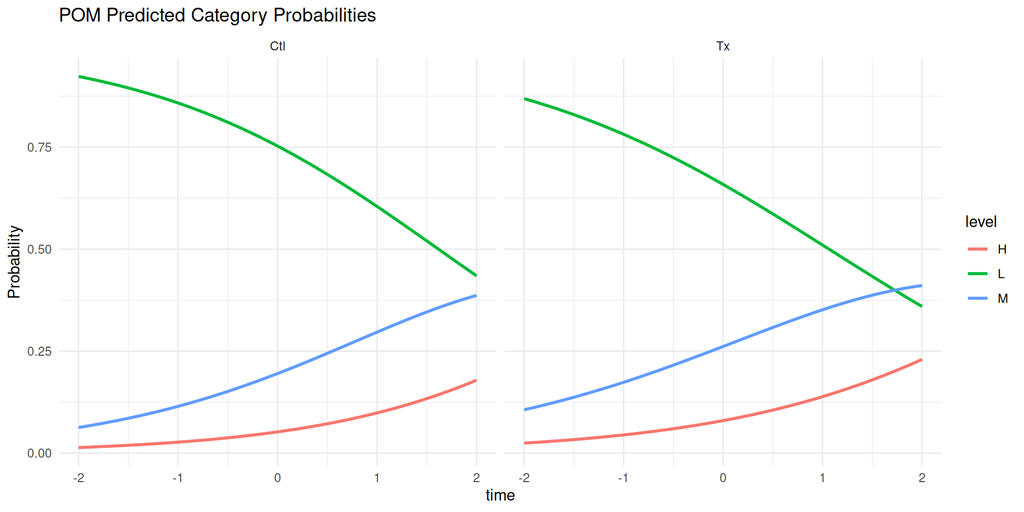

# Part 5 (Day 2): GLM Diagnostics

**Note**

**Beyond FLW Ch. 11 (instructor extension).** Deviance/Pearson residuals, leverage, Cook’s distance, and influence plots for GLMs are not defined in FLW Ch. 11; the chapter’s only fit tool is the overdispersion scale factor (Section 11.5). Leverage and Cook’s distance are the standard ordinary-regression diagnostics (LM, Ch. 3-6 / standard logistic-regression literature) extended to GLMs here; the $2\bar h$ and $4/n$ rules are stated locally below. Pace: ~15 min.

## Diagnostic Goals for GLMs

Single reference table (used by both the logistic and Poisson diagnostics above):

| Goal | What to Check | Tool |
| --- | --- | --- |
| Link adequacy | Does $g(\mu)$ linearize the relationship? | residual-vs-fitted curvature |
| Mean-variance | Does variance match the assumed $v(\mu)$? | Pearson residual spread, $\hat\phi$ |
| Influential points | Outliers affecting estimates? | leverage ($2\bar h$), Cook’s D ($4/n$) |
| Overdispersion | Variance exceeds model expectation? | $\hat\phi=$ Pearson $\chi^2/$df |
| Goodness-of-fit | Does the model fit overall? | deviance / LRT (FLW); H-L (enrichment) |

## Deviance and Pearson Residuals

$$r_i^{(P)} = \frac{y_i - \hat\mu_i}{\sqrt{\hat V(\hat\mu_i)}}, \qquad
r_i^{(D)} = \operatorname{sign}(y_i-\hat\mu_i)\sqrt{2\left[\ell(y_i)-\ell(\hat\mu_i)\right]}$$

| Residual Type | Based On |
| --- | --- |
| Pearson | scaled by estimated variance |
| Deviance | model log-likelihood contribution |

## Assessing Model Fit with Deviance

Residual deviance measures fit relative to the **saturated model** (the model with one parameter per observation, i.e. a perfect fit – the deviance is twice the log-likelihood gap between your model and that perfect fit).

Compare nested models via the likelihood-ratio test:

$$D = 2(\ell_{\text{full}} - \ell_{\text{reduced}}) \sim \chi^2_{df}$$

For nested models, smaller deviance indicates better fit. (This is FLW-native, Section 11.7.)

## Choosing the Link Function

**Note**

**Beyond FLW Ch. 11 (instructor extension):** complementary log-log and probit link choices are general GLM theory (McCullagh & Nelder 1989), not part of the Ch. 11 review.

| Link | Interpretation | Common Use |
| --- | --- | --- |
| Identity | direct mean | Normal |
| Logit | log-odds | binary |
| Log | log-rate | count |
| Probit | latent normal | binary / ordinal |
| Complementary log-log | asymmetric, rare events | survival-type data |

# Part 6 (Day 2): Extensions (read on your own)

**Note**

**Beyond FLW Ch. 11 (instructor extension).** Everything in Part 6 is enrichment: skim it, recognize the names, and know where to look. Pace: ~10 min, lecture-light.

## Zero-Inflated and Hurdle Models

**Note**

**Beyond FLW.** FLW (p. 321) mentions zero-inflated Poisson (ZIP) but states a detailed treatment is “beyond the scope of this chapter”; **hurdle** models are not in FLW at all (see Zeileis, Kleiber & Jackman 2008).

When counts have far more zeros than Poisson allows, use a two-part model:

| Part | Purpose |
| --- | --- |
| 1 | binary: structural zero vs “at risk” |
| 2 | count: conditional on being at risk |

```r
# Illustrative ZIP on the epilepsy counts (note: these are not zero-inflated,
# so this is a demonstration of syntax, not a recommended model here).
if (requireNamespace("pscl", quietly = TRUE)) {
  zi <- pscl::zeroinfl(total ~ trtf + base | 1, data = ep, dist = "poisson")
  round(coef(zi), 3)
} else {
  cat("Install 'pscl' for zero-inflated models.\n")
}
```

## Zero-Inflated and Hurdle Models

```
  count_(Intercept) count_trtfProgabide          count_base    zero_(Intercept)
              2.679              -0.206               0.022              -4.060
```

## Quasi-Likelihood and Robust (Sandwich) SEs

**Note**

**Beyond FLW Ch. 11 (instructor extension).** Sandwich/robust SEs are the bridge to GEE (Ch. 12-13); here they are previewed (see Zeger & Liang 1986).

For misspecified-variance or correlated data, robust (sandwich) SEs give valid inference even if the variance model is wrong.

```r
if (requireNamespace("sandwich", quietly = TRUE) &&
    requireNamespace("lmtest", quietly = TRUE)) {
  lmtest::coeftest(fit_pois, vcov = sandwich::sandwich)
} else {
  cat("Install 'sandwich' and 'lmtest' for robust SEs.\n")
}
```

## Quasi-Likelihood and Robust (Sandwich) SEs

```
z test of coefficients:

                Estimate Std. Error z value Pr(>|z|)
(Intercept)    0.0749927  0.3150986  0.2380   0.8119
trtfProgabide -0.1928933  0.1717332 -1.1232   0.2613
base           0.0225023  0.0012499 18.0034   <2e-16 ***
age            0.0162527  0.0099523  1.6331   0.1025
---
Signif. codes:  0 '***' 0.001 '**' 0.01 '*' 0.05 '.' 0.1 ' ' 1
```

## GEE Connection (Preview)

Single-level GLMs assume **independent** observations. Longitudinal data have within-subject correlation; Ch. 12-13 relax independence using GEE.

The GEE **working** covariance (NOT the true $\mathrm{Var}(\mathbf{Y}_i)$) is

$$V_i = \mathbf{A}_i^{1/2}\,\operatorname{Corr}(\mathbf{Y}_i)\,\mathbf{A}_i^{1/2},$$

where $\mathbf{A}_i$ is the diagonal of marginal variances and $\operatorname{Corr}(\mathbf{Y}_i)$ is a **working** correlation.

**Note**

Robust (sandwich) inference stays valid even if the working correlation is wrong. Standard GEE requires **MCAR** for valid inference; IPW-GEE extends to **MAR** (developed in the missing-data chapters, course L17-L18).

## Model Selection and AIC

**Note**

**Beyond FLW Ch. 11 (instructor extension):** AIC-based model selection is general practice (Akaike 1974), not part of the Ch. 11 review, which uses deviance/LRT for nested comparisons.

$$\text{AIC} = -2\ell + 2p$$

Smaller AIC = better fit/complexity tradeoff. Use the LRT (deviance) for **nested** models; AIC for **non-nested** comparison.

## Common Pitfalls

| Pitfall | Issue |
| --- | --- |
| Misinterpreting coefficients | odds/log-odds are not probabilities |
| Ignoring overdispersion | SEs too small, inflated significance |
| Log link with zero/negative values | model fails |
| Forgetting the offset | compares counts, not rates |
| Confusing nested vs non-nested comparison | wrong test (LRT vs AIC) |
| Misreading the ordinal sign convention | direction flips between polr and FLW |

## Further Reading

- Fitzmaurice, Laird & Ware (2011), *Applied Longitudinal Analysis*, Ch. 11 (course text)
- Dobson & Barnett (2018), *An Introduction to Generalized Linear Models* (GLM theory, IRLS)
- McCullagh & Nelder (1989), *Generalized Linear Models* (exponential family, links)
- Agresti (2015), *Foundations of Linear and Generalized Linear Models* (ordinal/multinomial)
- Hosmer, Lemeshow & Sturdivant (2013), *Applied Logistic Regression* (ROC, calibration, H-L)
- Zeileis, Kleiber & Jackman (2008), *Regression Models for Count Data in R* (ZIP, hurdle)

## GLM Summary: Key Takeaways

| Aspect | Key Point |
| --- | --- |
| Framework | GLMs extend LMs via a link + a mean-variance structure |
| Outcomes | binary, count, ordinal handled in one framework |
| FLW core | logistic ORs, Poisson rate ratios, overdispersion scale factor, deviance/LRT |
| Enrichment | ROC/AUC, calibration, H-L, ordinal/multinomial, ZIP, sandwich, AIC |

**Next Lecture:** Marginal Models (Ch. 12); GEE estimation follows in Ch. 13.

# Part 7: Appendices (Technical Details)

Beyond FLW Ch. 11; reference only.

## Appendix A: IRLS Algorithm Details

**Note**

**Beyond FLW Ch. 11.** Standard GLM theory (McCullagh & Nelder 1989).

Each iteration solves a weighted least-squares problem:

$$\boldsymbol{\beta}^{(t+1)} = (\mathbf{X}^\top W^{(t)} \mathbf{X})^{-1} \mathbf{X}^\top W^{(t)} z^{(t)}$$

with working response and weights

$$z^{(t)} = \eta^{(t)} + (y - \mu^{(t)}) \frac{d\eta}{d\mu},
\qquad
W^{(t)} = \operatorname{diag}\!\left[\left(\tfrac{d\mu}{d\eta}\right)^2 \big/ v(\mu)\right].$$

Here $d\mu/d\eta$ is the slope of the inverse link; $v(\mu)$ is the variance function.

## Appendix B: Score Function and Fisher Information

**Note**

**Beyond FLW Ch. 11.** Standard GLM theory; below assumes the **canonical link with unit dispersion** ($\phi=1$). The general forms carry $\phi$ and the $(\partial\mu_i/\partial\eta_i)^2$ weight.

For the canonical link (rows $X_{ij}$, $1\times p$):

$$U(\boldsymbol{\beta}) = \sum_i \sum_j X_{ij}^\top (Y_{ij} - \mu_{ij}),
\qquad
I(\boldsymbol{\beta}) = \sum_i \sum_j \frac{X_{ij}^\top X_{ij}}{\operatorname{Var}(Y_{ij})} .$$

Used for standard errors and likelihood inference.

## Appendix C: Exponential Family Examples

Using FLW’s labeling: cumulant function $a(\theta)$, data-only term $b(y,\phi)$, scale $\phi$.

| Distribution | $\phi$ | $a(\theta)$ (cumulant) | $b(y,\phi)$ (data-only) |
| --- | --- | --- | --- |
| Normal | $\sigma^2$ | $\theta^2/2$ | $-y^2/(2\sigma^2) - \tfrac12\log(2\pi\sigma^2)$ |
| Binomial | 1 | $\log(1+e^\theta)$ | $\log\binom{n}{y}$ |
| Poisson | 1 | $e^\theta$ | $-\log(y!)$ |

Recall $\mathbb{E}(Y)=a'(\theta)$ and $\mathrm{Var}(Y)=\phi\,a''(\theta)$.